# Mouse Forecast

Seasonal house mouse forecast for Australian grain-growing regions

## Outlook for Spring 2026

Predictions for September to November 2026

- Overall:
  - The plague in WA’s Northern (Geraldton) region is likely to continue.
  - Elsewhere, surveys have found mostly low mouse activity so far, but conditions have been outstanding in the south, with strong crop growth and, across much of SA and the Victorian Mallee, a recent dry-to-wet rainfall swing. In the north, good winter growth has been followed by a dry spring, which should ease the risk there if it continues.
  - The forecast points to moderate numbers in places (notably the Victorian Mallee, parts of the WA Sandplain, northern NSW and southern Queensland) and high numbers on SA’s Far West and Upper Eyre Peninsula, although that is very uncertain.
  - If populations build while these conditions last, plague risk could rise in the seasons ahead, so we have some cause for concern.
- Western Australia:
  - Northern (Geraldton): the plague has slowed but not crashed. Recent rainfall has favoured mice, and plagues can sometimes run into a second year.
  - Sandplain (Esperance): moderate in about a third of the region after exceptional winter crop growth.
  - Central and Eastern: mostly low.
- South Australia:
  - A recent dry-to-wet rainfall swing, which tends to precede plagues, points to high numbers on the Far West and Upper Eyre Peninsula and around Jamestown. This is very uncertain, as few recent surveys exist there.
  - Mostly low elsewhere, but the rainfall swing means any area where numbers reach moderate in future seasons could quickly progress to a plague.
- Victoria: Moderate in the Mallee north of Birchip (towards Sea Lake and Swan Hill) after excellent winter crop growth; with the recent rainfall swing, these populations could progress to a plague, so we are watching closely. Low elsewhere.
- New South Wales: Mostly low. Good winter growth raised the chance of a build-up (about even in the north, around Moree and Gunnedah; one in three elsewhere), but the dry spring and low survey results so far make this less likely.
- Queensland: Mostly low. Good winter growth raised the chance of a build-up to about even on the Darling Downs and along the border (around Dalby and Goondiwindi), lower around St George, but the dry spring and low survey results so far make this less likely. The forecast is least reliable here.

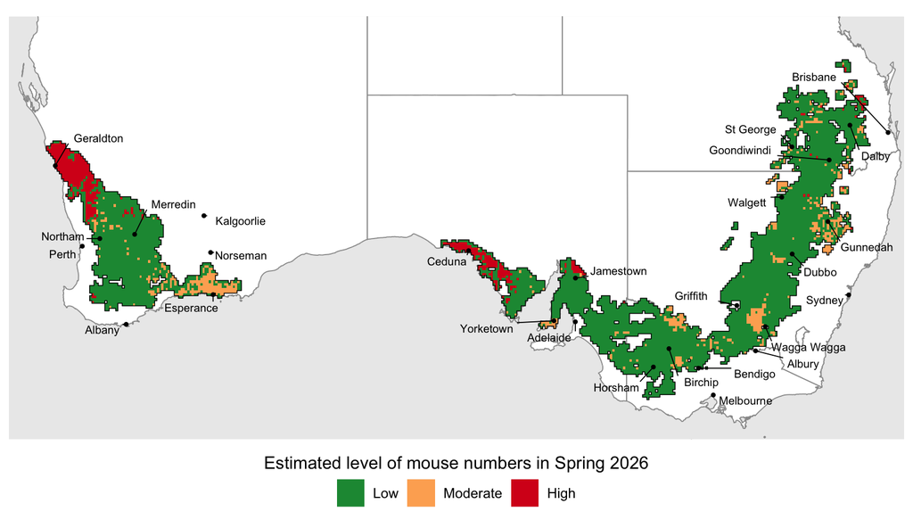

Figure 1: Most likely level of mouse numbers in Spring 2026 predicted across key grain growing areas (shown at a 10 x 10 km spatial resolution). “Low” numbers reflect typical yearly fluctuations in mouse numbers, with “moderate” numbers rising above normal levels (potentially in a build-up phase), and “high” approaching or at plague-like numbers. Current season forecast depends on mouse survey data, environmental conditions in the previous season, and this season’s surveys at nearby paddocks.

## Management recommendations

Disclaimer: forecasts and recommendations are prepared by CSIRO researchers from the data and resources available, and should only be used as a guide when making business decisions.

- Monitor mouse activity in crops before harvest, particularly in areas shaded red in Figure 2 below.
- Monitor using chew cards or a walk-through checking for crop damage ([GRDC: know your mouse numbers](https://grdc.com.au/resources-and-publications/resources/mouse-management/monitor-manage/know-your-mouse-numbers)). Active burrow counts are generally less reliable at this time of year due to poor visibility.
- Aim for a clean harvest with minimal grain loss to reduce food for mice in stubble, particularly where a wet finish delays harvest. Keep monitoring after harvest, as mouse numbers then set the risk for next season’s sowing.
- If you find mice or damage after harvest, consider applying zinc phosphide bait ([GRDC: mouse baiting](https://grdc.com.au/resources-and-publications/resources/mouse-management/monitor-manage/mouse-baiting)) before sowing. Most winter crops are now close to maturity, and bait becomes less attractive once grain develops in the head, so in-crop baiting is only worthwhile in crops still well short of maturity (be aware of the 14-day withholding period specified by the label).
- Growers sowing summer crops should check paddocks and neighbouring stubble before planting, and consider baiting at or immediately after sowing if mice are present.
- ZnP25 is registered nationally. Use it according to the label and report any adverse effects via the [APVMA adverse experience reporting program](https://www.apvma.gov.au/regulation/adverse-experience-reporting-program). An emergency permit currently allows use of the higher-dose ZnP50 bait. Check where it applies, its conditions and its expiry on the [GRDC mouse management page](https://grdc.com.au/resources-and-publications/resources/mouse-management).

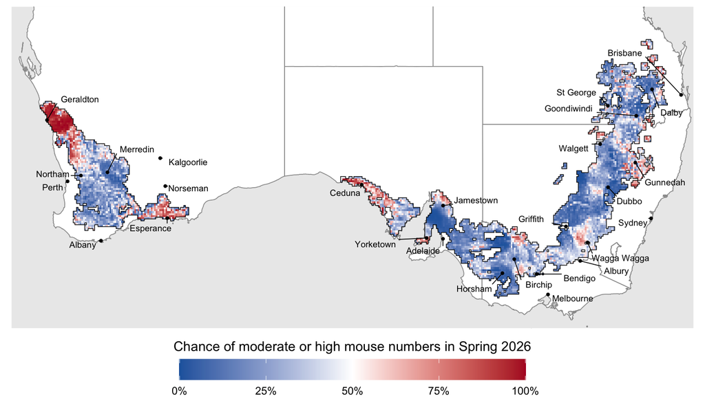

Figure 2: Chance of mouse numbers being moderate or high in Spring 2026, a level where growers should monitor mouse numbers in paddocks and be prepared to take management action. Red shows where mouse numbers are more likely to be moderate-high than low. Blue shows where mouse numbers are more likely to be low than to be moderate-high. White areas within the grain growing regions (outlined in black) show equal probability of being low or moderate-high (i.e., same chance as a coin toss).

## Report mouse activity

Take 60 seconds to report mouse activity on your farm on [MouseAlert](https://feralscan.org.au/mousealert).

We are primarily seeking observations from within paddocks (not houses or farm sheds), and particularly encourage reporting of low activity – not just observations of high mouse activity. This helps both inform and validate our forecasts.

## About

Mouse forecasts are enabled through a [Grains Research and Development Corporation and CSIRO investment into the 2025-29 Mouse Monitoring and Surveillance project](https://groundcover.grdc.com.au/grdc/announcements/investments-target-new-normal-of-mouse-activity) via the [Rodent Pest Management team](https://research.csiro.au/rm/). Forecasts will be updated seasonally or as new data becomes available.

We are actively testing and improving the statistical forecast model, and working on its presentation. This work is run in coordination with the National Mouse Group, a grower-led network of farmers, industry representatives, state government, GRDC and CSIRO. The group meets three times a year to update local reports of the current mouse situation, review management recommendations and determine research priorities.

### Monitoring data

Mouse population surveys are conducted 3–4 times a year at each of the ~170 long-term monitoring sites. Mice are surveyed through active burrow searches and chew cards. To calibrate this data against more robust population density measurements, we also conduct live-trapping at 4 sites (Adelaide Plains SA, Northern Mallee VIC, Central West NSW and Moree NSW).

Mouse monitoring data is collected by CSIRO, NSW Local Land Services, NSW Department of Primary Industries and Regional Development, Central West Farming Services, Birchip Cropping Group, and Farmanco. We also thank NSW DPIRD, who generously provide additional live-trapping survey data. Further live-trapping data is also occasionally supplied through the [GRDC / CSIRO Mouse Ecology 2024-2029 project](https://research.csiro.au/rm/research-projects/mouse-ecology-2024-2029/).

We also receive reports from farmers, agronomists and other community members directly. This is key information we consider given we cannot feasibly survey every paddock across the entire grain growing region.

### How the forecast works

- **A statistical model.** The forecast comes from a model built on more than 40 years of mouse surveys, which estimates which of three levels of mouse numbers to expect next season.
- **Three levels.** Mouse numbers move from **low** to **moderate**, usually after conditions turn good, and from moderate to **high**, most often after a sharp swing from dry to wet conditions. Moderate and high can both fall back to low when good conditions end.
- **What drives predictions.** Satellite crop growth over recent months, soil moisture over the past 6 to 12 months, rainfall swings, temperature, soil type, and whether a plague has just ended in the region set the chance of each move.
- **This season’s surveys.** Where paddocks have already been surveyed this season, their results update the forecast for the surrounding area (within about 25 km, in the same state). Areas far from any survey rely on conditions alone.
- **How far ahead.** One season, since it uses observed conditions, not weather forecasts.
- **How reliable.** Tested against recorded plague years before 2013, which the model never saw, it gives good warning in New South Wales, South Australia and Victoria and little in Queensland. It can’t yet be tested in Western Australia, which has no reliable plague records over that period.

### Contact

Questions about the forecast? Get in touch with Dr Matthew Rees matt.rees@csiro.au.

For media enquiries, contact Research Officer Steve Henry steve.henry@csiro.au or the [CSIRO media office](https://www.csiro.au/en/news/Media-Centre).

We value your feedback.

## 📬 Stay updated

Receive seasonal mouse forecasts to your inbox